# homework answers 4

Steve Simon

May 17, 2018

1. Open the WHAS500 data set in the software program of your choice.

```r
library(broom)
library(dplyr)
```

```r
library(ggplot2)
library(magrittr)
library(survival)
library(tidyr)
fn <- "../../data/whas500.RData"
load(fn)
head(whas500)
```

```
##   id age gender hr sysbp diasbp      bmi cvd afb sho chf av3     miord
## 1  1  83   Male 89   152     78 25.54051  No Yes  No  No  No Recurrent
## 2  2  49   Male 84   120     60 24.02398  No  No  No  No  No     First
## 3  3  70 Female 83   147     88 22.14290  No  No  No  No  No     First
## 4  4  70   Male 65   123     76 26.63187 Yes  No  No Yes  No     First
## 5  5  70   Male 63   135     85 24.41255  No  No  No  No  No     First
## 6  6  70   Male 76    83     54 23.24236 Yes  No  No  No Yes     First
##       mitype year  admitdate    disdate      fdate los dstat lenfol fstat
## 1 Non Q-wave 1997 01/13/1997 01/18/1997 12/31/2002   5 Alive   2178 Alive
## 2     Q-wave 1997 01/19/1997 01/24/1997 12/31/2002   5 Alive   2172 Alive
## 3     Q-wave 1997 01/01/1997 01/06/1997 12/31/2002   5 Alive   2190 Alive
## 4     Q-wave 1997 02/17/1997 02/27/1997 12/11/1997  10 Alive    297  Dead
## 5     Q-wave 1997 03/01/1997 03/07/1997 12/31/2002   6 Alive   2131 Alive
## 6 Non Q-wave 1997 03/11/1997 03/12/1997 03/12/1997   1  Dead      1  Dead
##      time_yrs
## 1 5.963039014
## 2 5.946611910
## 3 5.995893224
## 4 0.813141684
## 5 5.834360027
## 6 0.002737851
```

1. Calculate a Cox regression model systolic blood pressure (sysbp) by itself …

```r
whas500$time_yrs <- whas500$lenfol / 365.25
cox_sysbp <- coxph(
  Surv(time_yrs, fstat=="Dead")~sysbp,
    data=whas500)
summary(cox_sysbp)
```

```
## Call:
## coxph(formula = Surv(time_yrs, fstat == "Dead") ~ sysbp, data = whas500)
##
##   n= 500, number of events= 215
##
##            coef exp(coef)  se(coef)     z Pr(>|z|)
## sysbp -0.004520  0.995490  0.002226 -2.03   0.0423 *
## ---
## Signif. codes:  0 '***' 0.001 '**' 0.01 '*' 0.05 '.' 0.1 ' ' 1
##
##       exp(coef) exp(-coef) lower .95 upper .95
## sysbp    0.9955      1.005    0.9912    0.9998
##
## Concordance= 0.558  (se = 0.021 )
## Rsquare= 0.008   (max possible= 0.993 )
## Likelihood ratio test= 4.19  on 1 df,   p=0.04058
## Wald test            = 4.12  on 1 df,   p=0.04232
## Score (logrank) test = 4.12  on 1 df,   p=0.04227
```

… and then adjusted for gender and age.

```r
i_female <- as.numeric(whas500$gender=="Female")
cox_sysbp_adj <- coxph(
  Surv(time_yrs, fstat=="Dead")~sysbp+age+i_female,
    data=whas500)
summary(cox_sysbp_adj)
```

```
## Call:
## coxph(formula = Surv(time_yrs, fstat == "Dead") ~ sysbp + age +
##     i_female, data = whas500)
##
##   n= 500, number of events= 215
##
##               coef exp(coef)  se(coef)      z Pr(>|z|)
## sysbp    -0.004277  0.995732  0.002176 -1.966   0.0493 *
## age       0.066564  1.068829  0.006177 10.777   <2e-16 ***
## i_female -0.054134  0.947305  0.140807 -0.384   0.7006
## ---
## Signif. codes:  0 '***' 0.001 '**' 0.01 '*' 0.05 '.' 0.1 ' ' 1
##
##          exp(coef) exp(-coef) lower .95 upper .95
## sysbp       0.9957     1.0043    0.9915     1.000
## age         1.0688     0.9356    1.0560     1.082
## i_female    0.9473     1.0556    0.7188     1.248
##
## Concordance= 0.736  (se = 0.021 )
## Rsquare= 0.254   (max possible= 0.993 )
## Likelihood ratio test= 146.3  on 3 df,   p=0
## Wald test            = 124.5  on 3 df,   p=0
## Score (logrank) test = 131.8  on 3 df,   p=0
```

Is there evidence that systolic blood pressure shows any trends with respect to gender or age?

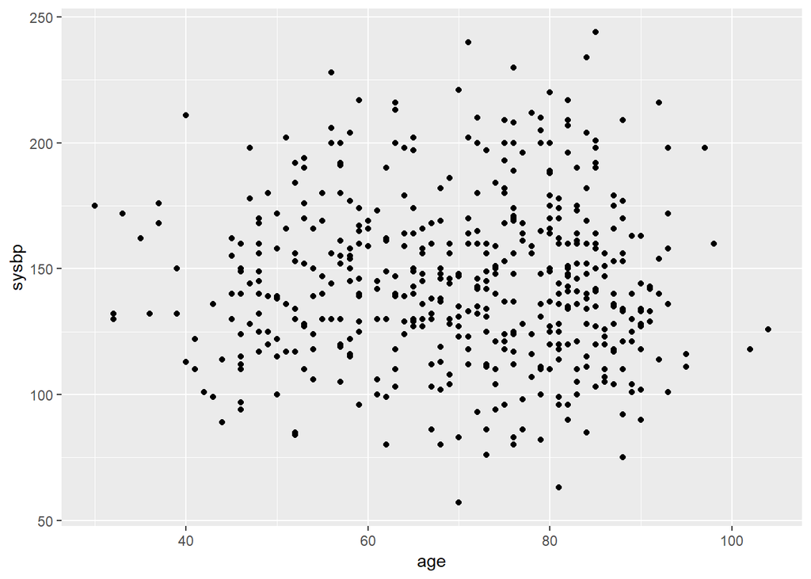

```r
ggplot(data=whas500, aes(age, sysbp)) +
  geom_point()
```

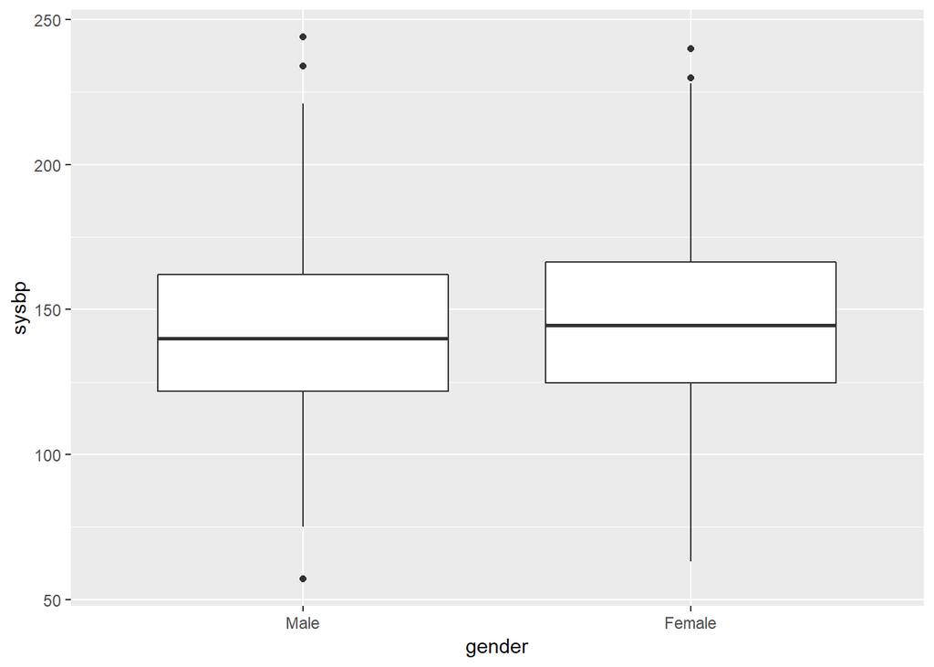

```r
ggplot(data=whas500, aes(gender, sysbp)) +
  geom_boxplot()
```

Calculate the unadjusted survival curves for patients with systolic blood pressures of 120, 140, and 160.

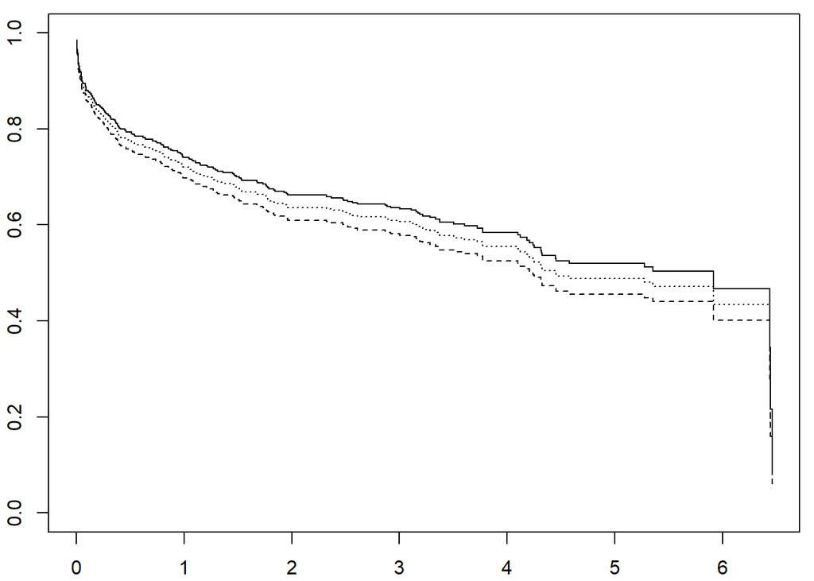

```r
n_unadjusted <-
  data.frame(
    sysbp=c(120, 140, 160))
predict_unadjusted <- survfit(cox_sysbp, newdata=n_unadjusted)
par(mar=c(2.1, 2.1, 0.6, 0.6))
plot(
  predict_unadjusted$time,
  predict_unadjusted$surv[, 3],
  type="s", ylim=c(0,1))
lines(
  predict_unadjusted$time,
  predict_unadjusted$surv[, 2],
  type="s", lty="dotted")
lines(
  predict_unadjusted$time,
  predict_unadjusted$surv[, 1],
  type="s", lty="dashed")
```

Then recalculate these survival curves with age set to the overall average age, and to a population that is 30% female. Interpret your results.

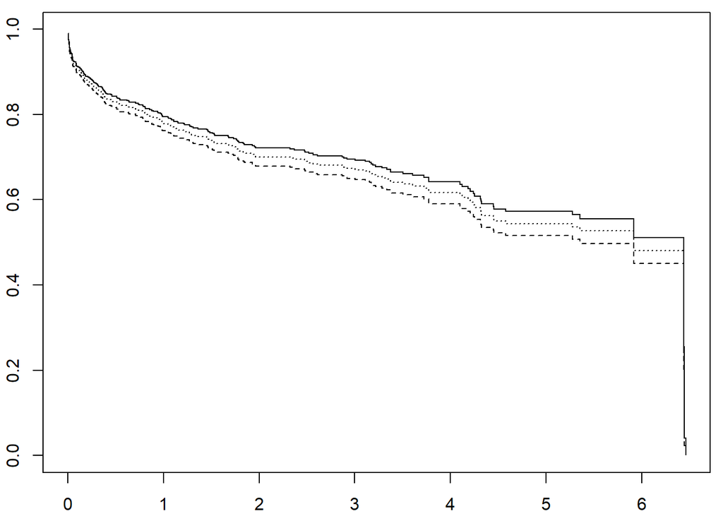

```r
n_adjusted <-
  data.frame(
    i_female=0.3,
    age=mean(whas500$age),
    sysbp=c(120, 140, 160))
predict_adjusted <- survfit(cox_sysbp_adj, newdata=n_adjusted)
par(mar=c(2.1, 2.1, 0.6, 0.6))
plot(
  predict_adjusted$time,
  predict_adjusted$surv[, 3],
  type="s", ylim=c(0,1))
lines(
  predict_adjusted$time,
  predict_adjusted$surv[, 2],
  type="s", lty="dotted")
lines(
  predict_adjusted$time,
  predict_adjusted$surv[, 1],
  type="s", lty="dashed")
```

2. Calculate cubic spline model for systolic blood pressure with four degrees of freedom.

```r
cox_pspline4 <- coxph(
  Surv(time_yrs, fstat=="Dead") ~
    pspline(sysbp, df=4),
      data=whas500)
cox_pspline4
```

```
## Call:
## coxph(formula = Surv(time_yrs, fstat == "Dead") ~ pspline(sysbp,
##     df = 4), data = whas500)
##
##                               coef se(coef)      se2    Chisq   DF     p
## pspline(sysbp, df = 4), l -0.00423  0.00200  0.00200  4.47698 1.00 0.034
## pspline(sysbp, df = 4), n                             7.88091 3.04 0.050
##
## Iterations: 5 outer, 12 Newton-Raphson
##      Theta= 0.839
## Degrees of freedom for terms= 4
## Likelihood ratio test=12.8  on 4.04 df, p=0.0128  n= 500
```

Plot this spline and offer an informal assessment as to whether your spline function deviates markedly from a linear relationship.

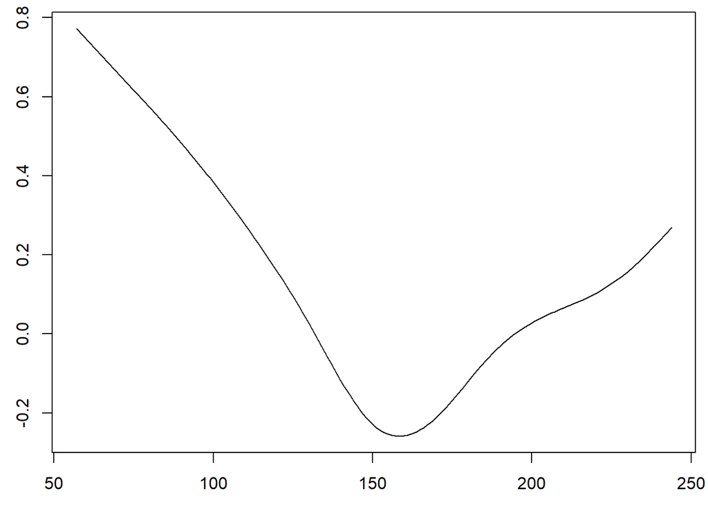

```r
terms_pspline4 <- predict(cox_pspline4, type="terms")
par(mar=c(2.6, 2.6, 0.6, 0.6))
o <- order(whas500$sysbp)
plot(whas500$sysbp[o], terms_pspline4[o , 1], type="l")
```

```r
glance(cox_sysbp)                 %>%
  bind_rows(glance(cox_pspline4)) %>%
  mutate(lab=c(
    "linear (df=1)",
    "spline (df=4)"))             %>%
  select(lab, logLik, AIC, BIC)   -> compare_splines
compare_splines
```

```
## # A tibble: 2 x 4
##   lab           logLik   AIC   BIC
##   <chr>          <dbl> <dbl> <dbl>
## 1 linear (df=1) -1225. 2452. 2456.
## 2 spline (df=4) -1221.   NA    NA
```

3. Calculate the Martingale residuals from your Cox model with a linear term for systolic blood pressure and for age and a term for gender. Plot these residuals versus diastolic blood pressure. Offer an informal assessment as to whether diastolic blood pressure adds any information to a model already including systolic blood pressure. Repeat this residual plot analysis using myocardial infection type (mitype).